# 1-Simulação hamiltoniana

#### A Equação que queremos simular é:

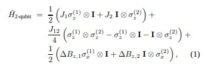

#### H3:

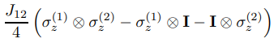

## 2- Fase: Teste das porções individuais com parametros setados como 1.

#### Nesta fase separamos os circuitos das hamiltonianas e fizemos a comparação com os resultados clássicos. Ainda nesta faze foi utilizado uma simulação de computador quantico para efetuar os testes e nenhum modelo de erro foi utilizado. Foi efetuado a comparação sem trotter-suzuki, com trotter-suzuki primeira ordem e segunda ordem.

## Simulação H1

#### A simulaçao do H1 foi feita com sucesso para t=1, a implementação de trotter de segunda ordem bateu a de primeira com n=10, a de primeira ordem precisou de 1000 pedaços de tempo para chegar no mesmo resultado.

Nota:Preciso confirmar se foi realmente isso que aconteceu devido aos resultados que eu obtive em H2, ainda estava chegando em um circuito e posso ter feito correções após implementação de trotter-suzuki)

### O cicuito para h1 é:

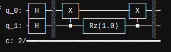

### Quantica identica a classica:

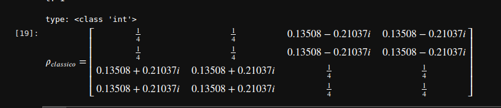

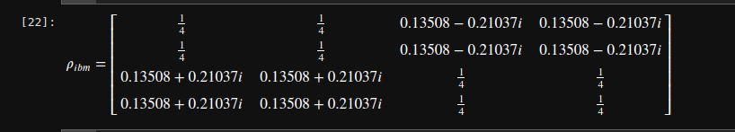

## Simulação H2

#### O circuito para H2 ficou:

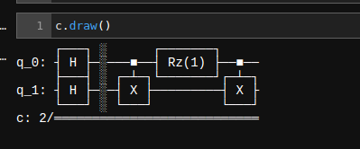

#### Matrix densidade quantica (Sem trotter-suzuki):

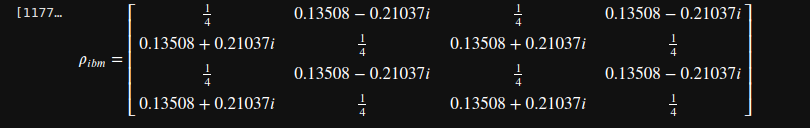

#### Matrix densidade classica:

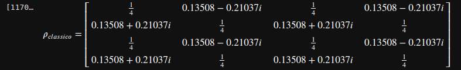

#### O circuito para H2 com trotter suzuki primeira ordem, é:

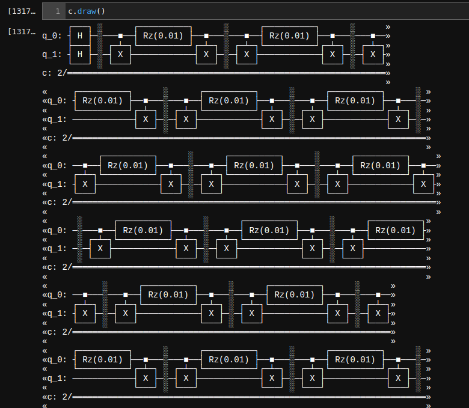

##### OBS: é apenas uma parte do circuito quando j2=1 e n = 100(n nesse contexto é o numero de divisões, no algoritmo representado pela letra r! atenção professor.)

#### O circuito da imagem é apenas uma pequena parcela do total. O circuito trata-se apenas de uma repetição de n-vezes do circuito de H2 unico.

#### Resultados: Matrix densidade quântica identica para os 3 testes, sem trotter-suzuki, com totter-suzuki primeira ordem e segunda, independente do valor de n colocado.

## Simulação H3

### Comecei tentando simular a expressão inteira, mas acho que não dá para simular dessa forma. Acho que quando passamos a formula de trotter suzuki houve um mal entendido da minha parte, e eu dividi de acordo com os termos que multiplicam os parametros. Tentei simular o circuito completo e não consegui. Porisso subdividi o H3 em mais 3 partes.

### Sem mais delongas, segue a equação h3 parte 1:

### Lembrando que tem um termo de 1/4 multiplicando o J12 que faz parte do parametro deste termo. Então, como os outros circuitos eram multiplicados por 1/2 e não precisamos multiplicar o resultado por causa da maneira como o gate é implementada, neste circuito vamos multiplicar a entrada por 1/2 por ele corresponder a parte de 1/4.

#### O circuito para H3-1 ficou:

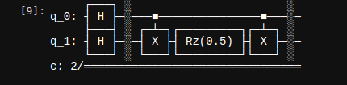

#### Matrix densidade quantica (Sem trotter-suzuki):

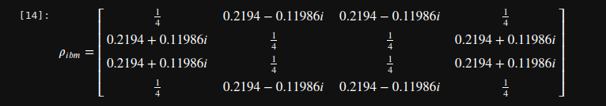

#### Matrix densidade classica:

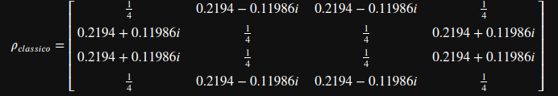

#### O circuito h3-2 e h3-2, são identicos ao circuito h1. apenas seu parametro é dividido por -1/2. O circuito foi testado e todas as matrizes corresponderam ao desejado.

## Simulação H4

#### O circuito para H4 ficou:

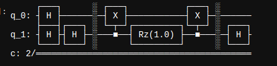

## Simulação H5

#### O circuito para h5 ficou:

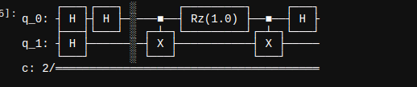

## 3- Fase: Teste de todos os circuitos juntos com parametros setados como 1.

#### Nesta fase meu objetivo é juntar todos os circuitos testados na fase anterior, o que representa a hamiltoniana completa.

#### O circuito:

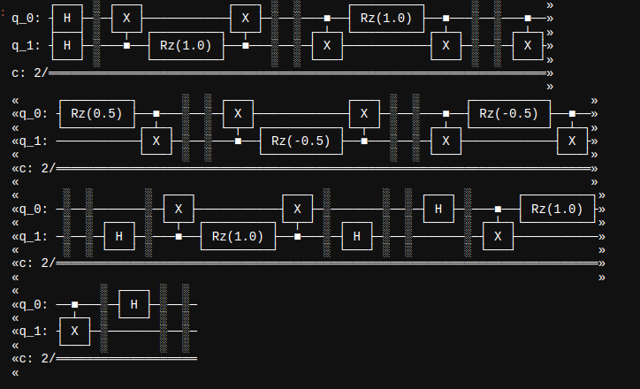

#### O resultado para trotter deprimeira ordem não deu certo com o n que eu consigo testar aqui de forma prática. O resultado da trotter-suzuki de segunda ordem com n=100000 é o abaixo:

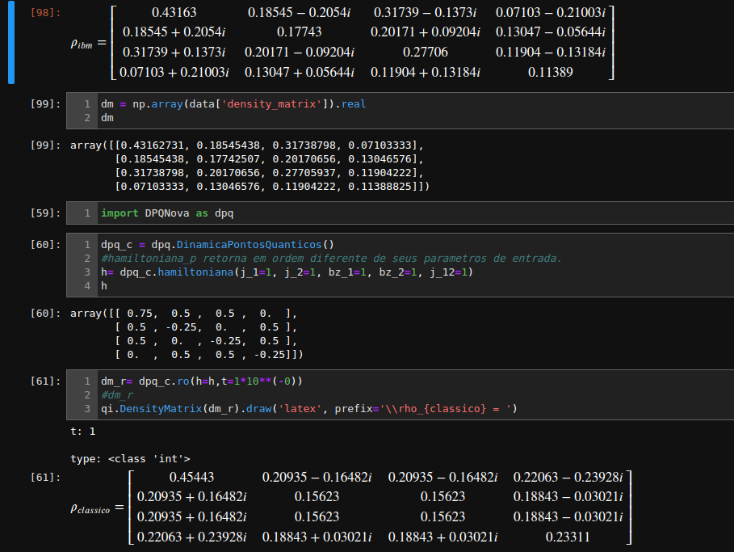